# Stat 331/531: Midterm Exam Open-Ended Analysis

Author

Trycia Vong

Published

May 8, 2025

### Take-Home Questions

```r
library(tidyverse)
library(knitr)
library(janitor)

minimum_wage_data <- read_csv('us-minimum-wage-data.csv') |>
  clean_names()

party_data <- read_csv('us-party-data.csv')
```

**Question 1.**

```r
#https://stackoverflow.com/questions/38649533/case-when-in-mutate-pipe, https://chatgpt.com/share/681d03ce-598c-8009-a7e1-bc5bc09253fc

data_clean <- minimum_wage_data |>
  mutate(year = year(effective_date)) |>
  left_join(party_data,by = join_by(year, state)) |>
  mutate(party = case_when(str_detect(pres_elect, "DEMOCRAT") ~ "Democrat",
                           str_detect(pres_elect, "REPUBLICAN") ~ "Republican")) |>
  mutate(prop_pop = str_extract(pres_elect, "\\(([^)]+)\\)")) |>
  mutate(prop_pop = str_remove_all(prop_pop, "[()%]")) |>
  mutate(prop_pop = as.numeric(prop_pop)) |>
  mutate(prop_pop = prop_pop / 100)

slice_tail(data_clean, n = 2) |>
  kable()
```

| effective_date | state | state_minimum_wage | state_minimum_wage_2020_dollars | federal_minimum_wage | federal_minimum_wage_2020_dollars | effective_minimum_wage | effective_minimum_wage_2020_dollars | cpi_average | department_of_labor_uncleaned_data | department_of_labor_cleaned_low_value | department_of_labor_cleaned_low_value_2020_dollars | department_of_labor_cleaned_high_value | department_of_labor_cleaned_high_value_2020_dollars | footnote | year | pres_elect | party | prop_pop |
| --- | --- | --- | --- | --- | --- | --- | --- | --- | --- | --- | --- | --- | --- | --- | --- | --- | --- | --- |
| 2020-01-01 | Wisconsin | 7.25 | 7.25 | 7.25 | 7.25 | 7.25 | 7.25 | 258.66 | 7.25 | 7.25 | 7.25 | 7.25 | 7.25 | NA | 2020 | DEMOCRAT (49.45%) | Democrat | 0.4945 |
| 2020-01-01 | Wyoming | 5.15 | 5.15 | 7.25 | 7.25 | 7.25 | 7.25 | 258.66 | 5.15 | 5.15 | 5.15 | 5.15 | 5.15 | NA | 2020 | REPUBLICAN (69.5%) | Republican | 0.6950 |

**Question 2.**

```r
# https://chatgpt.com/share/681d11cb-4ce0-8009-a23f-b4a00fa40149

data_clean |>
  filter(year == 1990 | year == 2000 | year == 2010) |>
  drop_na(pres_elect, party) |>
  mutate(strength = case_when(prop_pop >= 0.55 ~ "Strong",
                              prop_pop > 0.5 & prop_pop < 0.55 ~ "Moderate",
                              prop_pop <= 0.5 ~ "Weak" ),
         strength = factor(strength, levels = c("Strong", "Moderate", "Weak"))) |>
  select(state, state_minimum_wage_2020_dollars, year : strength) |>
  group_by(party, strength, year) |>
  summarise(avg_min_wage = round(mean(state_minimum_wage_2020_dollars), 2), .groups = "drop") |>
  pivot_wider(names_from = year, values_from = avg_min_wage, names_prefix = "avg_") |>
  kable()
```

| party | strength | avg_1990 | avg_2000 | avg_2010 |
| --- | --- | --- | --- | --- |
| Democrat | Strong | 7.22 | 8.07 | 9.05 |
| Democrat | Moderate | 5.88 | 8.39 | 8.31 |
| Democrat | Weak | NA | 7.79 | 8.60 |
| Republican | Strong | 4.55 | 5.34 | 5.69 |
| Republican | Moderate | 5.56 | 4.84 | 6.38 |
| Republican | Weak | NA | 4.92 | 6.67 |

### Open-Ended Analysis

**Description**: The data I will be using is the state’s minimum wage from the years 1968 to 2020. The data includes the 50 U.S. states, plus Washington D.C., Guam, and Puerto Rico. The other data set is presidential voting information for US states from 1976 to 2020 (excludes Washington D.C. and US territories). The regions are separated by East region, West Region and Central Region.

**Research Questions**: Do the coastal regions tend to have higher minimum wage than the central region? Does political leanings of regions influence minimum wage?

**Description of Table**: The table shows the average minimum wage per region by party from the years 1976 to 2020.

**Table**:

```r
east_region <- c(
  "Maine", "New Hampshire", "Vermont", "Massachusetts", "Rhode Island",
  "Connecticut", "New York", "New Jersey", "Pennsylvania", "Delaware",
  "Maryland", "Virginia", "West Virginia", "North Carolina",
  "South Carolina", "Georgia", "Florida"
)

central_region <- c(
  "Ohio", "Indiana", "Illinois", "Michigan", "Wisconsin",
  "Minnesota", "Iowa", "Missouri", "North Dakota", "South Dakota",
  "Nebraska", "Kansas", "Kentucky", "Tennessee", "Mississippi",
  "Alabama", "Arkansas", "Louisiana", "Texas", "Oklahoma"
)

west_region <- c(
  "Montana", "Idaho", "Wyoming", "Colorado", "New Mexico",
  "Arizona", "Utah", "Nevada", "California", "Oregon",
  "Washington", "Alaska", "Hawaii"
)

data_clean <- data_clean |>
  mutate(region = case_when(state %in% east_region ~ "East Region",
                            state %in% central_region ~ "Central Region",
                            state %in% west_region ~ "West Region")) |>
  drop_na(region) |>
  select(state, state_minimum_wage_2020_dollars, year, party : region)

number_party <- data_clean |>
  drop_na(party) |>
  count(party, region)

minimum_wages <- data_clean |>
  drop_na(party) |>
  group_by(party, region) |>
  summarise(avg_min_wage = round(mean(state_minimum_wage_2020_dollars), 2))

inner_join(number_party, minimum_wages, join_by(party, region)) |>
  arrange(region) |>
  kable()
```

| party | region | n | avg_min_wage |
| --- | --- | --- | --- |
| Democrat | Central Region | 252 | 6.48 |
| Republican | Central Region | 648 | 4.91 |
| Democrat | East Region | 433 | 8.12 |
| Republican | East Region | 332 | 6.13 |
| Democrat | West Region | 208 | 8.52 |
| Republican | West Region | 377 | 6.64 |

**Description of Plot**: The plot is showing the average minimum wage per region from the year 1968 to 2020.

**Plot**:

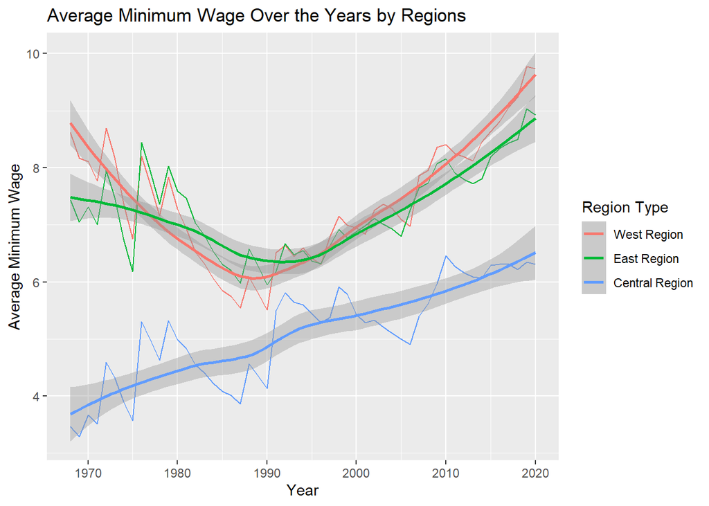

```r
# https://chatgpt.com/share/681d2989-5628-8009-b3e8-b6a8303fb6f0

data_clean |>
  group_by(region, year) |>
  summarise("avg_minimum_wage" = mean(state_minimum_wage_2020_dollars), .groups = "drop") |>

  ggplot(aes(x = year, y = avg_minimum_wage, color = fct_reorder2(.x = year,
                                                                 .y = avg_minimum_wage,
                                                                 .f = region))) +
  geom_line() +
  geom_smooth(method = loess) +
  labs(title = "Average Minimum Wage Over the Years by Regions", x = "Year", y = "Average Minimum Wage", color = "Region Type")
```

**Conclusion**: Based on the analyses from the table we can confidently say that political leanings of regions do influence the minimum wage. And we can see that the democratic areas of the region consistently have higher minimum wages than the republican areas which can be due to political views on stimulating the economy. Also from the plot we can conclude that coastal regions do have a higher minimum wage compared to the central region which can be due to desirable location and weather leading to higher costs.